# Case Study Cyclistic

Vitor Alves Raquel

2022-06-08

Case study for Google Data Analytics Certificate’s capstone project.

## Initial considerations

Annual members are much more profitable than casual riders.

The insights from the analysis could clarify the differences between annual members and casual riders to design marketing strategies aimed at converting casual riders into annual members.

Customers who purchase single-ride or full-day passes are referred to as casual riders. Customers who purchase annual memberships are Cyclistic members.

Understand how do annual members and casual riders use Cyclistic bikes differently.

## Data

The original data is available at: https://divvy-tripdata.s3.amazonaws.com/index.html The data licence can be found here: https://ride.divvybikes.com/data-license-agreement

The data was collected by the company and was organized for this analysis in a directory to keep the original data unchanged. Each month has its own subdirectory containing a CSV file, comprehending the last 12 months, from June 2021 to May 2022.

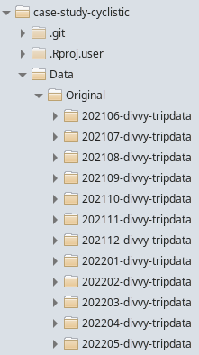

Directory structure

The merging and cleaning was made on cyclistic_cleaning.Rmd, which saves the file “df.Rda” on “Data” directory.

```r
wd <- "/home/vitor/RStudio-projects/case-study-cyclistic"
input_file <- "Data/df.Rda"

setwd(wd)
Sys.setlocale("LC_ALL", "C")
load(input_file)
```

## Analysis

```r
library(tidyverse)
library(lubridate)
library(vtable)
```

### Members and casual users comparison.

View column names to guide the analysis.

```r
colnames(df)
```

```
##  [1] "rideable_type"      "started_at"         "ended_at"
##  [4] "start_station_name" "start_station_id"   "end_station_name"
##  [7] "end_station_id"     "start_lat"          "start_lng"
## [10] "end_lat"            "end_lng"            "member_casual"
## [13] "trip_duration"      "month_year"         "day"
## [16] "day_of_week"        "start_int_hour"
```

```r
sumtable(df[c("rideable_type", "member_casual", "trip_duration")],
         add.median = TRUE)
```

Summary Statistics

| Variable | N | Mean | Std. Dev. | Min | Pctl. 25 | Pctl. 50 | Pctl. 75 | Max |
| --- | --- | --- | --- | --- | --- | --- | --- | --- |
| rideable_type | 5763874 |  |  |  |  |  |  |  |
| … classic_bike | 3174410 | 55.1% |  |  |  |  |  |  |
| … docked_bike | 272722 | 4.7% |  |  |  |  |  |  |
| … electric_bike | 2316742 | 40.2% |  |  |  |  |  |  |
| member_casual | 5763874 |  |  |  |  |  |  |  |
| … casual | 2521974 | 43.8% |  |  |  |  |  |  |
| … member | 3241900 | 56.2% |  |  |  |  |  |  |
| trip_duration | 5763874 | 1261.842 | 9966.696 | 61 | 394 | 693 | 1251 | 3356649 |

#### Trip duration

Values smaller than 1 minute are excluded, since they could represent false starts or users trying to re-dock, according to the data description at https://ride.divvybikes.com/system-data.

Duration values longer than one day are considered as lost or stolen bikes, according to https://help.divvybikes.com/hc/en-us/articles/360033484791-What-if-I-keep-a-bike-out-too-long-. In this analysis, they will be referred as missing.

Trip duration longer than one day by customer type:

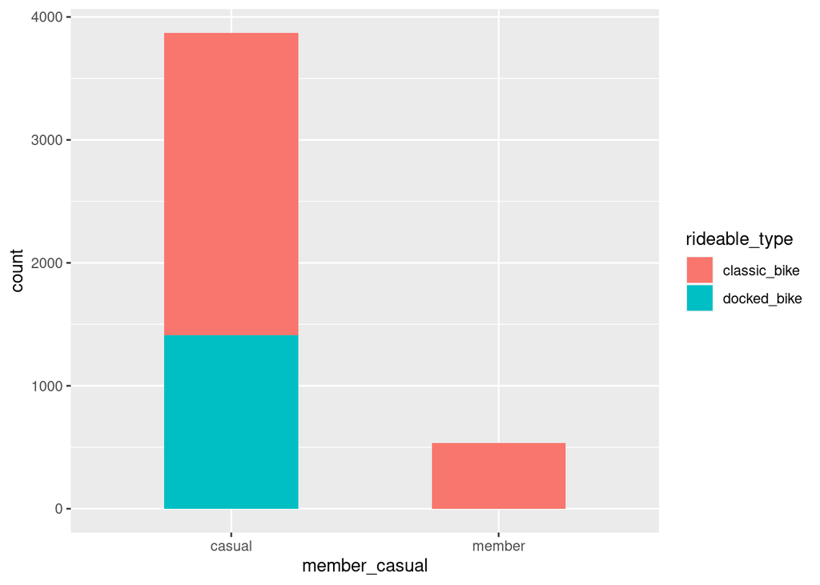

```r
ggplot(data = df[df$trip_duration > 86400, ]) +
    geom_bar(width = 0.5, mapping = aes(x = member_casual, fill = rideable_type))
```

There are no electric bikes missing, this can be due to battery depletion or some tracking device included only on this model. - Discuss with the technical team to find out what is avoiding the electrical bikes to go missing and if it is a device that can be installed on the other model.

Trip duration values higher than one day will be not considered from now on.

```r
df <- df[df$trip_duration <= 86400, ]
```

Comparing trip duration by customer type:

```r
df %>% group_by(member_casual) %>%
    summarise(mean_duration = hms::as_hms(round(mean(trip_duration))),
              median_duration = hms::as_hms(round(median(trip_duration))))
```

```
## # A tibble: 2 x 3
##   member_casual mean_duration median_duration
##   <chr>         <time>        <time>
## 1 casual        25'52"        15'29"
## 2 member        13'02"        09'17"
```

Plotting trip duration shorter than 1 hour:

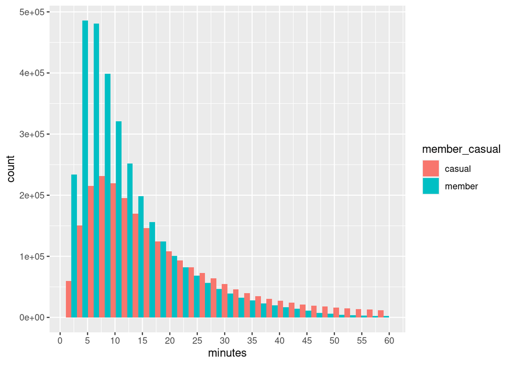

```r
ggplot(data = df[df$trip_duration < 3600,]) +
    geom_histogram(position = position_dodge()) +
    aes(x = trip_duration, fill = member_casual) +
    scale_x_continuous(breaks = seq(0, 3600, 300), labels = seq(0, 60, 5),
                       name = "minutes")
```

Comparing trip duration for both customer types by day of the week.

```r
dur_day <- df %>%
    group_by(day_of_week, member_casual) %>%
    summarise(mean_duration = hms::as_hms(round(mean(trip_duration))))
dur_day
```

```
## # A tibble: 14 x 3
## # Groups:   day_of_week [7]
##    day_of_week member_casual mean_duration
##    <ord>       <chr>         <time>
##  1 Sun         casual        29'36"
##  2 Sun         member        14'44"
##  3 Mon         casual        26'12"
##  4 Mon         member        12'37"
##  5 Tue         casual        23'11"
##  6 Tue         member        12'16"
##  7 Wed         casual        22'38"
##  8 Wed         member        12'21"
##  9 Thu         casual        22'57"
## 10 Thu         member        12'24"
## 11 Fri         casual        24'15"
## 12 Fri         member        12'47"
## 13 Sat         casual        28'19"
## 14 Sat         member        14'37"
```

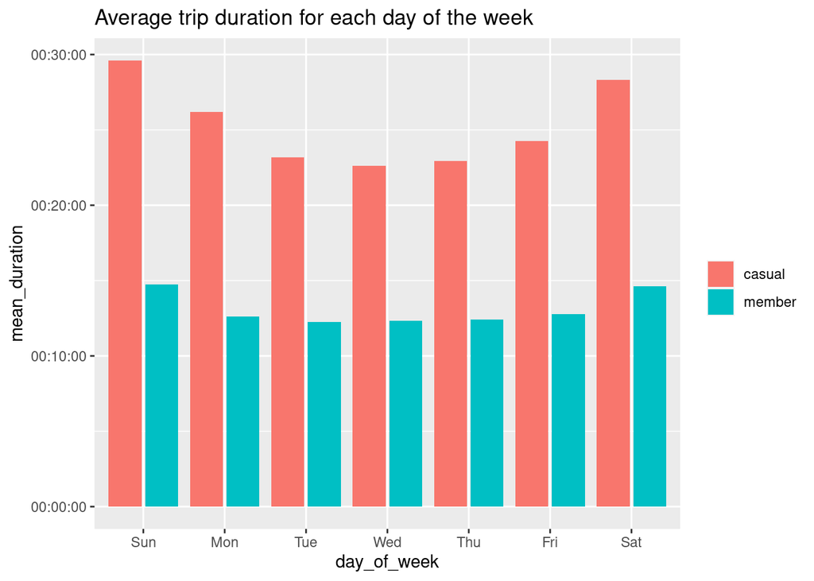

```r
ggplot(dur_day, aes(x = day_of_week, y = mean_duration, fill = member_casual)) +
    geom_bar(stat = "identity", position = position_dodge2(width = 1)) +
    labs(title = "Average trip duration for each day of the week") +
    theme(legend.title = element_blank())
```

#### Trip count

```r
table(df$member_casual)
```

```
##
##  casual  member
## 2518102 3241366
```

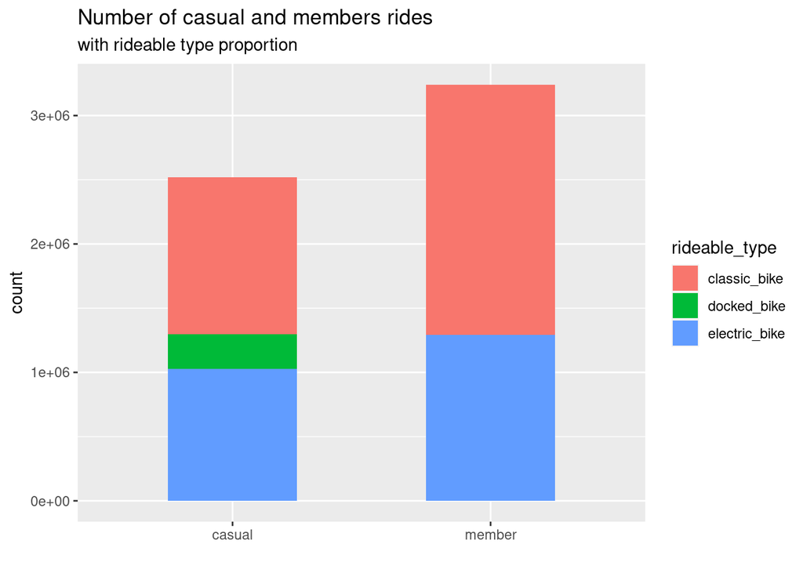

```r
ggplot(data = df) +
    geom_bar(width = 0.5, mapping = aes(x = member_casual,
                                        fill = rideable_type)) +
    labs(title = "Number of casual and members rides",
         subtitle = "with rideable type proportion", x = "")
```

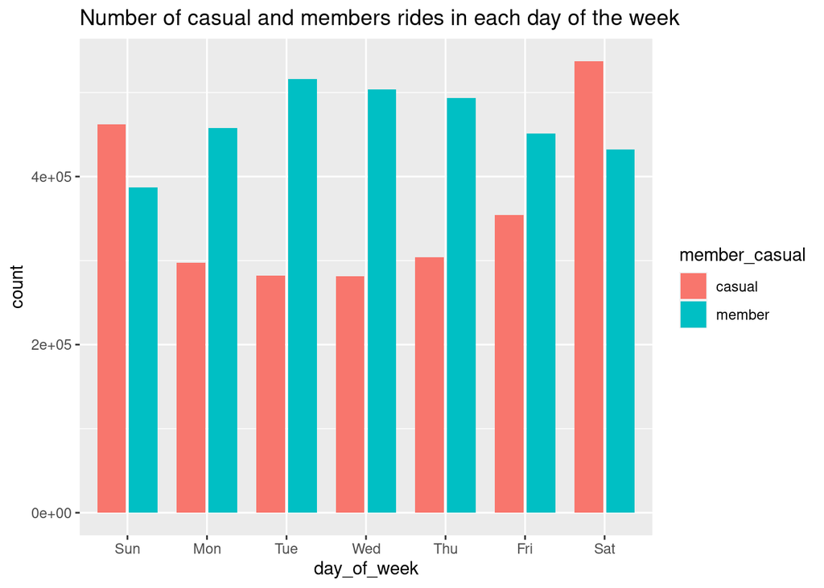

```r
ggplot(data = df) +
    geom_bar(position = position_dodge2(width = 1),
             width = 0.8, mapping = aes(x = day_of_week, fill = member_casual)) +
    labs(title = "Number of casual and members rides in each day of the week" )
```

Since the total number of member trips is higher than casual trips, their behavior would be better expressed in percentage of total trips for each group.

```r
day_of_week_df <- as.data.frame(table(df$member_casual, df$day_of_week))
colnames(day_of_week_df) <- c("member_casual", "day_of_week", "trips")

trip_count <- day_of_week_df %>%
    group_by(member_casual) %>%
    summarise(total_trips = sum(trips))

day_of_week_df <- left_join(day_of_week_df, trip_count) %>%
    mutate(percent = 100 * trips / total_trips)
```

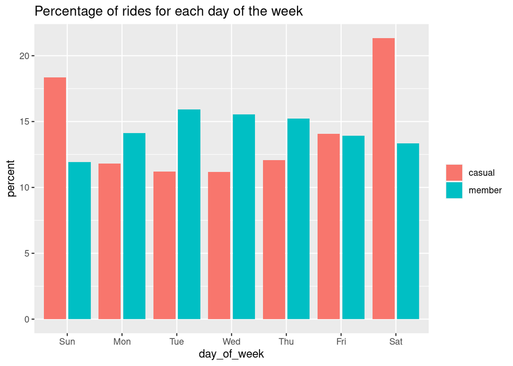

```r
ggplot(day_of_week_df, aes(x = day_of_week, y = percent, fill = member_casual)) +
    geom_bar(stat = "identity", position = position_dodge2(width = 1)) +
    labs(title = "Percentage of rides for each day of the week") +
    theme(legend.title = element_blank())
```

Casual riders use the service more on weekends and members on weekdays. This suggests that members use bikes while commuting.

This can be further explored by comparing the time of the day when trips happen for both groups.

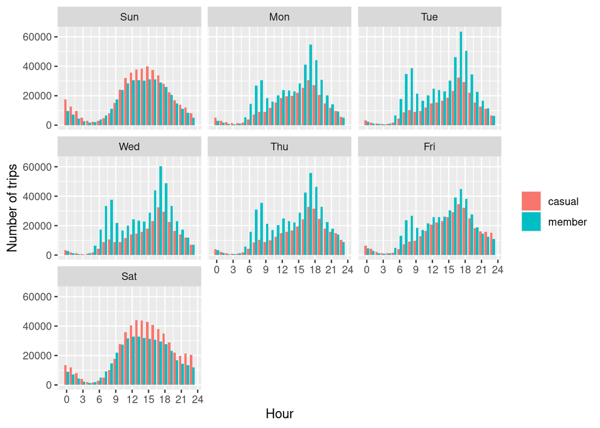

```r
ggplot(data = df) +
    geom_bar(position = position_dodge()) +
    facet_wrap("day_of_week") +
    scale_x_continuous(breaks = seq(0, 24, 3)) +
    aes(x = start_int_hour, fill = member_casual) +
    labs(x = "Hour", y = "Number of trips") +
    theme(legend.title = element_blank())
```

```r
hour_df <- df %>%
    group_by(member_casual, day_of_week, start_int_hour) %>%
    summarise(total_hour = length(member_casual)) %>%
    left_join(trip_count) %>%
    mutate(percent = 100 * total_hour / total_trips)
```

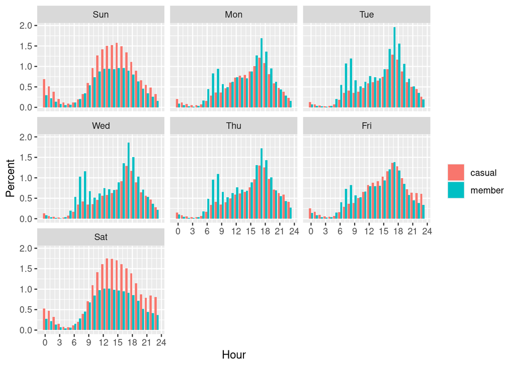

```r
ggplot(data = hour_df) +
    geom_bar(position = position_dodge(), stat = "identity") +
    facet_wrap("day_of_week") +
    scale_x_continuous(breaks = seq(0, 24, 3),
                       minor_breaks = seq(0, 24)) +
    aes(x = start_int_hour, y = percent, fill = member_casual) +
    labs(x = "Hour", y = "Percent") +
    theme(legend.title = element_blank())
```

The shape of the plots are very different for weekends and weekdays and they confirm that members use the service more to commute to work than casuals, while casuals use more on weekends than members.

```r
total_hour_df <- hour_df %>%
    mutate(day_of_week = ifelse(grepl("S(at|un)", day_of_week),
                            "weekend", "weekday")) %>%
    group_by(member_casual, day_of_week, start_int_hour, total_trips) %>%
    summarise(total_hour = sum(total_hour)) %>%
    mutate(percent = 100 * total_hour / total_trips)
```

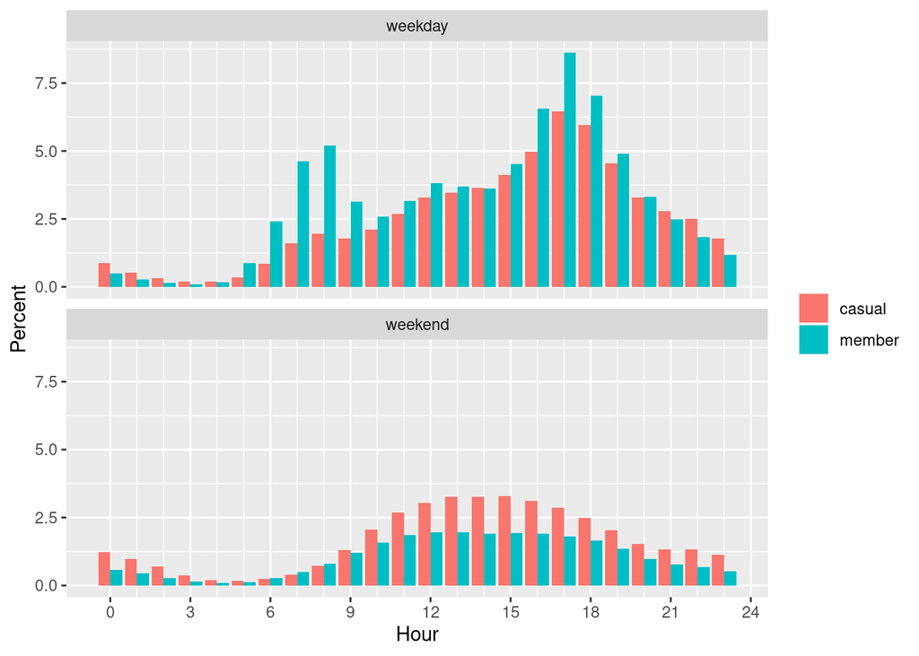

```r
ggplot(data = total_hour_df) +
    geom_bar(position = position_dodge(), stat = "identity") +
    facet_wrap("day_of_week", dir = "v") +
    scale_x_continuous(breaks = seq(0, 24, 3),
                       minor_breaks = seq(0, 24)) +
    aes(x = start_int_hour, y = percent, fill = member_casual) +
    labs(x = "Hour", y = "Percent") +
    theme(legend.title = element_blank(),
          panel.spacing.x = )
```

analyze months

```r
month_df <- df %>%
    group_by(member_casual, month_year) %>%
    summarise(total_month = length(member_casual)) %>%
    left_join(trip_count) %>%
    mutate(percent = 100 * total_month / total_trips)
```

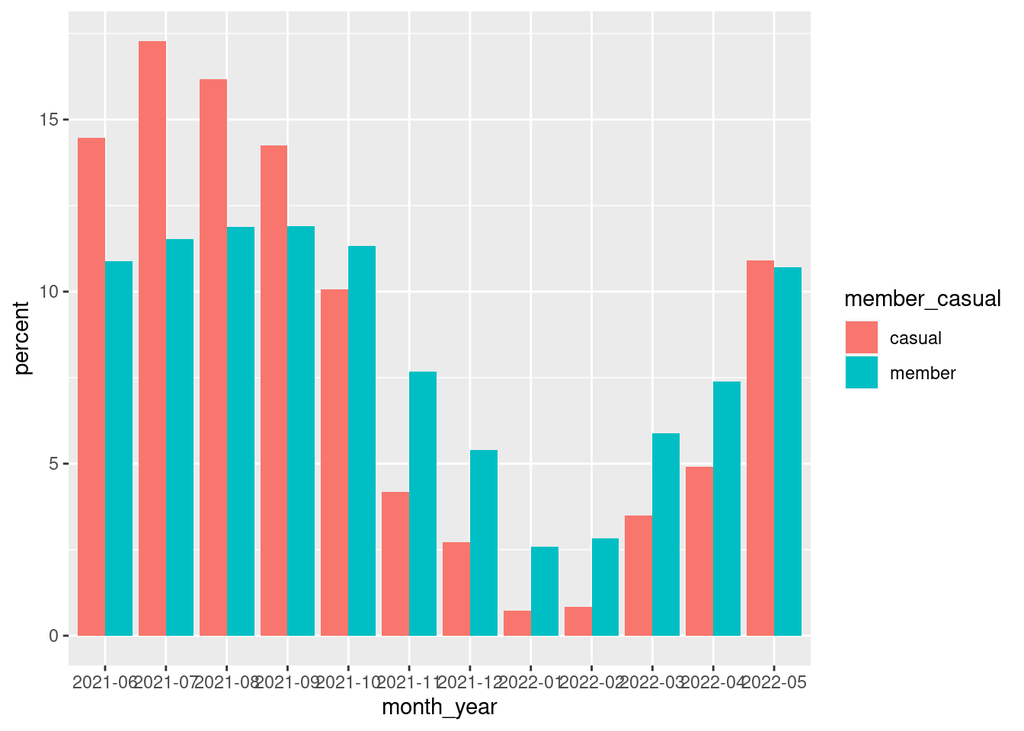

```r
ggplot(data = month_df) +
    geom_bar(position = position_dodge(), stat = "identity") +
    aes(x = month_year, y = percent, fill = member_casual)
```

```r
day_df <- df %>%
    group_by(member_casual, month_year, day) %>%
    summarise(total_day = length(member_casual)) %>%
    left_join(trip_count) %>%
    mutate(percent = 100 * total_day / total_trips)
```

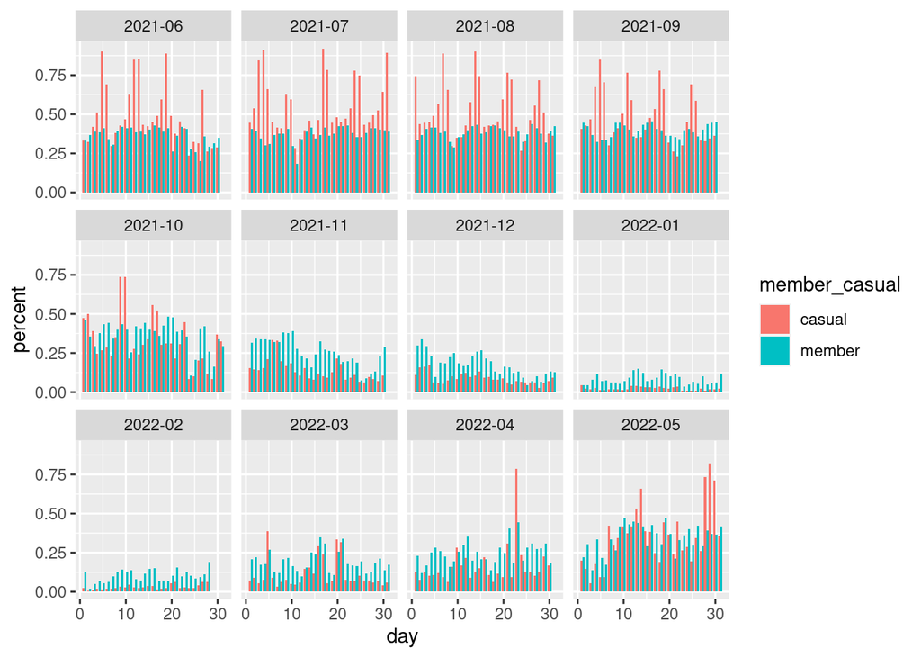

```r
ggplot(data = day_df) +
    geom_bar(position = position_dodge(), stat = "identity") +
    facet_wrap("month_year") +
    aes(x = day, y = percent, fill = member_casual)
```